# AB InBev: Strategic Business Ventures & Opportunities

Javier Saldana

October 20, 2018

We are excited to bring you an exciting development and new business opportunity that we believe would help Anheuser-Busch InBev employ rapid entry to market, without disruption of current production. In 2017, Bud Light (#1) and Budweiser (#3) remained in the Top 3 of Best Selling Beer in USA, yet they (along with many others) saw a decline in market share. Millennials are drinking wine over beer. At the same time, the growing Hispanic population is driving the increase in demand for Mexican brand beers (Corona and Modelo). In addition, the growing craft beer segment is maturing and starting to slow down. This puts Anheuser-Busch in a unique situation which they may be able to capitalize on in order to drive shareholder wealth! [source](https://www.usatoday.com/story/money/food/2018/07/04/top-selling-beers-in-america-budweiser-coors-heineken/36440871/)

## **Breweries Across America**

As you can see below (Figure 1), 10 states are home to over 50% of the breweries across the USA. In fact, Fort Collins, CO is home to a brewery from Anheuser-Busch! Yet, it is not the large breweries that set CO apart. Colorado’s craft beer scene is what is driving its brewery numbers high! A maturing market only indicates the “hype” of the market is fading away and the serious contenders are remaining. Considering the low entry cost for the craft beer market and the difficulty to scale the business, only those with established resources are able to survive long enough. Fortunately, AB InBev is one of those players. [source](http://www.cobizmag.com/Trends/Why-Colorado-reigns-as-the-Napa-Valley-of-beer/)

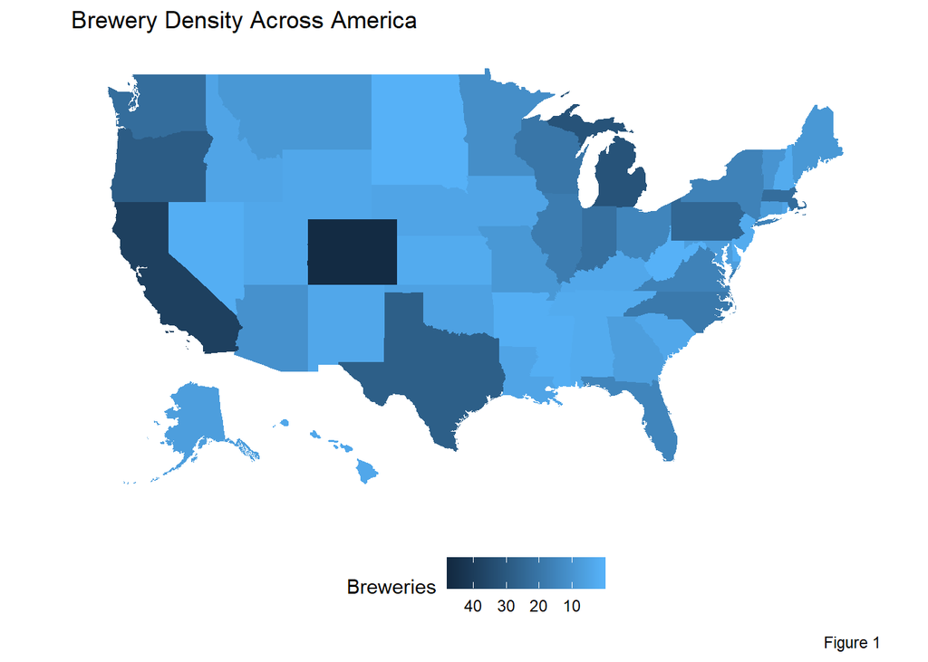

When we look at the numbers, we begin to see that 2410 beers are produced by these 558 breweries. Most of these breweries are situated in the Western region and Midwest with the exception of Texas, Massachusetts, and Pennsylvania. A brief illustration of the data’s first 6 (Figure 2) and final 6 (Figure 3) observations are demonstrated below. It is sorted by Brewery_id and includes various other descriptive characteristics of the beer and the location it was brewed.

| Brewery_id | Beer Name | Beer_ID | ABV | IBU | Style | Ounces | Brewery Name | City | State |
| --- | --- | --- | --- | --- | --- | --- | --- | --- | --- |
| 1 | Get Together | 2692 | 0.045 | 50 | American IPA | 16 | NorthGate Brewing | Minneapolis | MN |
| 1 | Maggie’s Leap | 2691 | 0.049 | 26 | Milk / Sweet Stout | 16 | NorthGate Brewing | Minneapolis | MN |
| 1 | Wall’s End | 2690 | 0.048 | 19 | English Brown Ale | 16 | NorthGate Brewing | Minneapolis | MN |
| 1 | Pumpion | 2689 | 0.060 | 38 | Pumpkin Ale | 16 | NorthGate Brewing | Minneapolis | MN |
| 1 | Stronghold | 2688 | 0.060 | 25 | American Porter | 16 | NorthGate Brewing | Minneapolis | MN |
| 1 | Parapet ESB | 2687 | 0.056 | 47 | Extra Special / Strong Bitter (ESB) | 16 | NorthGate Brewing | Minneapolis | MN |

* Figure 2

|  | Brewery_id | Beer Name | Beer_ID | ABV | IBU | Style | Ounces | Brewery Name | City | State |
| --- | --- | --- | --- | --- | --- | --- | --- | --- | --- | --- |
| 2405 | 556 | Pilsner Ukiah | 98 | 0.055 | NA | German Pilsener | 12 | Ukiah Brewing Company | Ukiah | CA |
| 2406 | 557 | Heinnieweisse Weissebier | 52 | 0.049 | NA | Hefeweizen | 12 | Butternuts Beer and Ale | Garrattsville | NY |
| 2407 | 557 | Snapperhead IPA | 51 | 0.068 | NA | American IPA | 12 | Butternuts Beer and Ale | Garrattsville | NY |
| 2408 | 557 | Moo Thunder Stout | 50 | 0.049 | NA | Milk / Sweet Stout | 12 | Butternuts Beer and Ale | Garrattsville | NY |
| 2409 | 557 | Porkslap Pale Ale | 49 | 0.043 | NA | American Pale Ale (APA) | 12 | Butternuts Beer and Ale | Garrattsville | NY |
| 2410 | 558 | Urban Wilderness Pale Ale | 30 | 0.049 | NA | English Pale Ale | 12 | Sleeping Lady Brewing Company | Anchorage | AK |

* Figure 3

Yet, as we dive deeper in the data we begin to notice there are some values missing. We can see that out of those 2410 beers, over 40% were missing an International Bitterness Unit (IBU). With how fast the craft beer industry turns over new beers, it is no surprise that we would have nearly half of the data set missing an IBU score. With respect to Alcohol By Volume (ABV), only 62 beers did not contain entries. Fortunately, there is no need for alarm. The remaining data is still sufficient to analyze and provide strong results we can be confident about. Figure 4 illustrates that none of the other variables were missing any data.

|  | N/As |
| --- | --- |
| Brewery_id | 0 |
| Beer Name | 0 |
| Beer_ID | 0 |
| ABV | 62 |
| IBU | 1005 |
| Style | 0 |
| Ounces | 0 |
| Brewery Name | 0 |
| City | 0 |
| State | 0 |

* Figure 4

## **Median ABV and IBU Across America**

While the popular Bud Light an Budweiser are in the moderate ABV and IBU range, we can see that the median ABV and IBU across the country are higher than the top selling beer. We get a quick overview of where the breweries are outputting beers. Since microbreweries don’t have the same distribution network as major companies, they tend to tailor to local tastes, which gives us a very strong indicator of what that state’s population is producing.

Yet, we also begin to see a noticeable trait of the variables. Figure 5, which demonstrates the median ABV by state, is relatively calm and shows very little variance between medians. However, figure 6 tells us a different story about the IBU of the beers. Unlike the ABV, the IBU scores are much more volatile and have a greater distribution between medians.

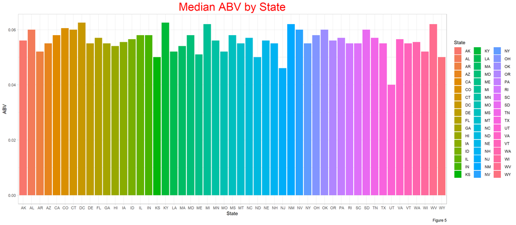

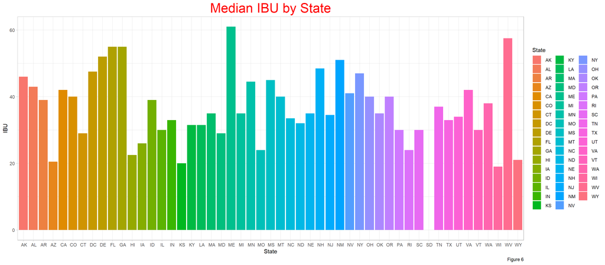

|  | ABV | State |
| --- | --- | --- |
| 375 | 0.128 | CO |

* Figure 7

|  | IBU | State |
| --- | --- | --- |
| 1857 | 138 | OR |

* Figure 8

## **Alcohol By Volume: A Closer Look**

```
##    Min. 1st Qu.  Median    Mean 3rd Qu.    Max.    NA's
## 0.00100 0.05000 0.05600 0.05977 0.06700 0.12800      62
```

```
## [1] "Figure 9"
```

## **What does it all mean?**

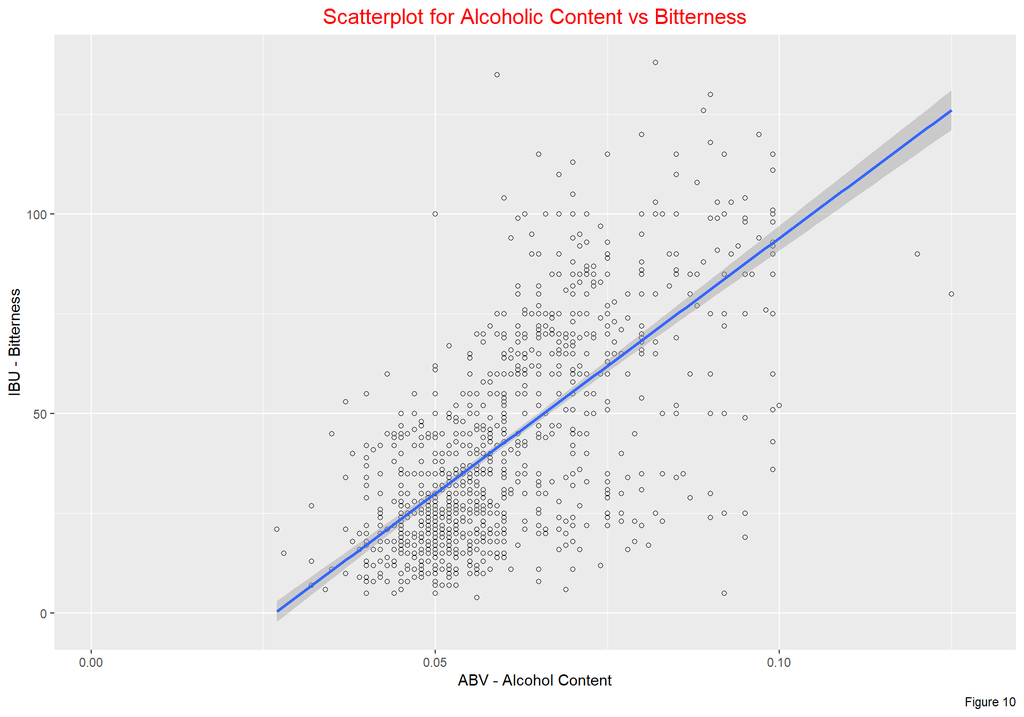

We believe the advantage of understanding the correlation positions Anheuser-Busch InBev in a strategic position with respects to the entry to market. With the most popular brands of Anheuser-Busch InBev averaging around 4% ABV, we believe the craft beer opportunities lie within the 5% - 6.7% ABV range. By developing a craft beer recipe within that range (or above) and an IBU that suits to the local consumer, Anheuser-Busch is able to then license out the recipe to microbreweries looking to sell their services. This will allow AB InBev to continue operations as normal, while benefiting from the royalties of licensing. Licensing is an attractive option for AB InBev because it is able to control the competitors that enter the market and tap into customers are different price points and taste points. Considering in licensing deals the licensee assumes the majority of the risk, we believe AB InBev will be able to not only recoup its investment but, if executed properly, continue to generate income and satisfy consumers across multiple segments of the beer market.

AB InBev is already at the top of the beer industry. Yet, only data and research such as this is going to help keep it there. With that said, thank you for taking the time to read this report.